# data_wrangling2

## Reloading Dataset

```python
import pandas as pd
import numpy as np

trainDf = pd.read_csv("./data/train.csv")
feaDf = pd.read_csv("./data/features.csv").drop(["IsHoliday"], axis=1)
storesDf = pd.read_csv("./data/stores.csv")


df1 = pd.merge(trainDf, feaDf, on = ["Store", "Date"])
#print(df1.shape)
train = pd.merge(df1, storesDf, on = "Store")
print("Dataset size:",train.shape)

#Rename column names
train.columns = ['Store', 'Dept', 'Date', 'Weekly_Sales', 'IsHoliday', 'Temperature',
       'Fuel_Price', 'MarkDown1', 'MarkDown2', 'MarkDown3', 'MarkDown4',
       'MarkDown5', 'CPI', 'Unemployment', 'Store_Type', 'Size']

display(train.head(3))
```

```
Dataset size: (421570, 16)
```

|  | Store | Dept | Date | Weekly_Sales | IsHoliday | Temperature | Fuel_Price | MarkDown1 | MarkDown2 | MarkDown3 | MarkDown4 | MarkDown5 | CPI | Unemployment | Store_Type | Size |
| --- | --- | --- | --- | --- | --- | --- | --- | --- | --- | --- | --- | --- | --- | --- | --- | --- |
| 0 | 1 | 1 | 2010-02-05 | 24924.50 | False | 42.31 | 2.572 | NaN | NaN | NaN | NaN | NaN | 211.096358 | 8.106 | A | 151315 |
| 1 | 1 | 2 | 2010-02-05 | 50605.27 | False | 42.31 | 2.572 | NaN | NaN | NaN | NaN | NaN | 211.096358 | 8.106 | A | 151315 |
| 2 | 1 | 3 | 2010-02-05 | 13740.12 | False | 42.31 | 2.572 | NaN | NaN | NaN | NaN | NaN | 211.096358 | 8.106 | A | 151315 |

```python
train.drop(columns=["MarkDown1","MarkDown2","MarkDown3","MarkDown4", "MarkDown5"], inplace = True)
display(train.head(5))
```

|  | Store | Dept | Date | Weekly_Sales | IsHoliday | Temperature | Fuel_Price | CPI | Unemployment | Store_Type | Size |
| --- | --- | --- | --- | --- | --- | --- | --- | --- | --- | --- | --- |
| 0 | 1 | 1 | 2010-02-05 | 24924.50 | False | 42.31 | 2.572 | 211.096358 | 8.106 | A | 151315 |
| 1 | 1 | 2 | 2010-02-05 | 50605.27 | False | 42.31 | 2.572 | 211.096358 | 8.106 | A | 151315 |
| 2 | 1 | 3 | 2010-02-05 | 13740.12 | False | 42.31 | 2.572 | 211.096358 | 8.106 | A | 151315 |
| 3 | 1 | 4 | 2010-02-05 | 39954.04 | False | 42.31 | 2.572 | 211.096358 | 8.106 | A | 151315 |
| 4 | 1 | 5 | 2010-02-05 | 32229.38 | False | 42.31 | 2.572 | 211.096358 | 8.106 | A | 151315 |

## Data Analysis

```python
import plotly.graph_objs as go
from plotly import __version__
from plotly.offline import download_plotlyjs, init_notebook_mode, plot, iplot
import plotly.offline as offline

init_notebook_mode(connected=True)
```

```python
namesLst=list(map(str,train.Store.unique()))
dateLst = train.Date.unique()

aa=[]
salesLst=[]
timeLst=[]
storeSalesDict={}
for name in namesLst:
    print(name)
    storeSalesDict[int(name)]=[]
    for date in dateLst:
        aa=round(train.Weekly_Sales[train.Store == int(name)][train.Date == date].sum()/ 1000000,2)
        storeSalesDict[int(name)].append(aa)
```

```
1
2
3
4
5
6
7
8
9
10
11
12
13
14
15
16
17
18
19
20
21
22
23
24
25
26
27
28
29
30
31
32
33
34
35
36
37
38
39
40
41
42
43
44
45
```

```python
traces=[]

for i, sales in storeSalesDict.items():
    #print(i, sales)
    traces.append(go.Scatter(
    x= pd.to_datetime(dateLst),
    y=sales,
    name="Store#"+str(i)
    ))
```

```python
import numpy as np
aa= np.zeros((len(storeSalesDict),len(storeSalesDict)))
aa = [[str(aa[i][j]) for i in range(0,aa.shape[0])] for j in range(0,aa.shape[1])]
aa = [[False for i in range(0,len(aa))] for j in range(0,len(aa))]
for i in range(len(aa)):
    aa[i][i] = True
```

```python
updatemenus = list([
    dict(type="buttons",
         active=-1,
         buttons=list([
            dict(label = 'Store 1',
                 method = 'update',
                 args = [{'visible': aa[0]},
                         {'title': 'Store 1 Sales'}])]))])

#[True, False, False, False,False, False, False]
```

```python
layout = go.Layout(
    title = 'Weekly Sales (Figure 1)',
    #yaxis =dict(autorange=True, showgrid=True,zeroline=True, autotick=False),

    autosize=True,
    #width=700,
    #height=1000,
    yaxis =dict(title = "Weekly Sales (in Millions)",
                exponentformat='e',
                showexponent='all',
                titlefont=dict(size=18),
                tick0=5,ticks="outside",
                dtick=1,
                tickwidth=2,
                showgrid=True),
    xaxis = dict(title="Time Series (in Months)",
                 titlefont=dict(size=18),
                 exponentformat='e',
                 showexponent='all',
                 zeroline=True,
                 showgrid=False,
                 rangeselector=dict(visible=True,
                                    buttons=list([
                                        dict(count=1,
                                             label="1m",
                                             step="month",
                                             stepmode ="backward"),
                                        dict(count=3,
                                                 label="3m",
                                                 step="month",
                                                 stepmode ="backward"),
                                         dict(count=6,
                                                 label="6m",
                                                 step="month",
                                                 stepmode ="backward"),
                                         dict(count=12,
                                                 label="12m",
                                                 step="month",
                                                 stepmode ="backward"),
                                        dict(step ="all")])),
                 rangeslider = dict(visible=True)
                ),
    margin = dict(l=60,r=30, b=80, t=40),
    showlegend=False,
    updatemenus=updatemenus
)
```

```python
fig = go.Figure(data=traces, layout=layout)
iplot(fig, show_link=True)
```

[interactive chart not shown]

- Sales impact with holidays or without holidays
- Average Sales (working Days vs holidays)
- Hypotheses: features vs Weeky_Sales

### Weekly Sales in Store_Type

The figure 2 below shows the total sales generated by different store type (i.e. A, B, C). Obiviously, the sales in regular working holidays takes the major proportion of the sales in holidays because holidays like Christmas and Thanksgiving only takes small portion throughout the year. However, in figure 3,we could observe that the average weekly sales in holidays is higher than weekly sales in working days for Type A, B stores. Sales are basically NO variant for type C store. To be more precise determine their sales performance between holidays or non-holidays, I would propose to set up hypothesis test to further verify.

```python
trace1 = []

salesA = train.Weekly_Sales[train.Store_Type=="A"][train.IsHoliday==False].sum()
salesB = train.Weekly_Sales[train.Store_Type=="B"][train.IsHoliday==False].sum()
salesC = train.Weekly_Sales[train.Store_Type=="C"][train.IsHoliday==False].sum()

trace1 = go.Bar(
    x = sorted(list(set(train.Store_Type))),
    y = [salesA, salesB, salesC],
    name = "Working day"
)

salesA = train.Weekly_Sales[train.Store_Type=="A"][train.IsHoliday==True].sum()
salesB = train.Weekly_Sales[train.Store_Type=="B"][train.IsHoliday==True].sum()
salesC = train.Weekly_Sales[train.Store_Type=="C"][train.IsHoliday==True].sum()

trace2=[]
trace2 = go.Bar(
    x = sorted(list(set(train.Store_Type))),
    y = [salesA, salesB, salesC],
    name = "Holiday"
)

data = [trace1, trace2]
layout = go.Layout(
    title = "Store Type Sale (%s to %s) - Total (Figure 2) "% (min(train.Date), max(train.Date)),
    barmode='group',
    showlegend=True,
    xaxis = dict(title = "Store Type"),
    yaxis = dict(title = " Total Sales")
)

fig = go.Figure(data=data, layout=layout)
iplot(fig, show_link=True)
```

[interactive chart not shown]

```python
#salesA_len= len(list(train.Weekly_Sales[train.Store_Type=="A"][train.IsHoliday==False]))
salesA_len = len(list(set(train.Date[train.Store_Type=="A"][train.IsHoliday==False])))
salesA_tot = train.Weekly_Sales[train.Store_Type=="A"][train.IsHoliday==False].sum()
salesA_avg = salesA_tot/ salesA_len

salesB_len= len(list(set(train.Date[train.Store_Type=="B"][train.IsHoliday==False])))
salesB_tot = train.Weekly_Sales[train.Store_Type=="B"][train.IsHoliday==False].sum()
salesB_avg = salesB_tot/ salesB_len

salesC_len= len(list(set(train.Date[train.Store_Type=="C"][train.IsHoliday==False])))
salesC_tot = train.Weekly_Sales[train.Store_Type=="C"][train.IsHoliday==False].sum()
salesC_avg = salesC_tot/ salesC_len

trace1 = go.Bar(
    x = sorted(list(set(train.Store_Type))),
    y = [salesA_avg, salesB_avg, salesC_avg],
    name = "Working day - " + str(salesA_len) + " days"
)

salesA_len= len(list(set(train.Date[train.Store_Type=="A"][train.IsHoliday==True])))
salesA_tot = train.Weekly_Sales[train.Store_Type=="A"][train.IsHoliday==True].sum()
salesA_avg = salesA_tot/ salesA_len

salesB_len= len(list(set(train.Date[train.Store_Type=="B"][train.IsHoliday==True])))
salesB_tot = train.Weekly_Sales[train.Store_Type=="B"][train.IsHoliday==True].sum()
salesB_avg = salesB_tot/ salesB_len

salesC_len= len(list(set(train.Date[train.Store_Type=="C"][train.IsHoliday==True])))
salesC_tot = train.Weekly_Sales[train.Store_Type=="C"][train.IsHoliday==True].sum()
salesC_avg = salesC_tot/ salesC_len

trace2 = go.Bar(
    x = sorted(list(set(train.Store_Type))),
    y = [salesA_avg, salesB_avg, salesC_avg],
    name = "Holiday - "+str(salesA_len) + " days"
)

data = [trace1, trace2]
layout = go.Layout(
    title = "Store Type Sale (%s to %s) - Weekly (Figure 3) "% (min(train.Date), max(train.Date)),
    barmode='group',
    showlegend=True,
    xaxis = dict(title = "Store Type"),
    yaxis = dict(title = " Weekly Sales ")
)

fig = go.Figure(data=data, layout=layout)
iplot(fig, show_link=True)
```

[interactive chart not shown]

### BarPlot - Sales vs Department

The figure 4 below shows the ranking of Department in terms of Weekly Sales. The highest weekly sales which is about $75000 is generated by Dept 92; The lowest weekly which is -#7.68 is generated by store 47. This plot could demonstrate the sales deficiency between stores.

```python
sales_dept = []
dept_lst=[]
lst=[]
for dept in list(set(train.Dept)):
    lst.append(tuple((dept,round(train.Weekly_Sales[train.Dept == dept].sum()/len(train.Weekly_Sales[train.Dept == dept]),2))))

df = pd.DataFrame(lst).sort_values(by=[1], ascending=True)
dept_lst = list(df.iloc[:,0])
sales_dept = list(df.iloc[:,1])

trace3 = []
trace3 = go.Bar(
    x = list(df.iloc[:,1]),
    y = list(map(str,list(df.iloc[:,0]))),
    orientation="h"
    #name = "Working day"
)

data = [trace3]
layout = go.Layout(
    #barmode='group',
    width=700,
    height=1200,
    #showlegend=True
    title = 'Average Weekly Sales Ranking (Figure 4)',
    yaxis =dict(title = "Department Number",
                #exponentformat='e',
                #showexponent='all',
                titlefont=dict(size=18),
                tick0=5,
                ticks="outside",
                dtick=1,
                tickwidth=2,
                showgrid=False,
                type='category'),
    xaxis = dict(title="Weekly Sales($)",
                 titlefont=dict(size=18),
                 zeroline=True,
                 #range=[2,5],
                 showgrid=True)
)

annotations=[]
for i in range(len(dept_lst)):
    annotations.append(dict(x=sales_dept[i],
                            y=dept_lst[i],
                            text="%0.2f"%(sales_dept[i]),
                            font=dict(family='Arial',
                                      size=12,
                                      color='red'),
                            showarrow=True,
                            align = "center",
                            ax=40,
                            ay=0,
                            arrowhead=0))
    layout['annotations'] = annotations


fig = go.Figure(data=data, layout=layout)
iplot(fig, show_link=True)
```

[interactive chart not shown]

## Correlation

Now, we are going to check whether the Store Weekly Sales is correlated with the following features.

- Weekly_Sales vs Temperature
- Weekly_Sales vs Fuel_Price
- Weekly_Sales vs CPI
- Weekly_Sales vs Size

Based on the following plots, it is difficult to determine the intensity of correlation between those features against Weekly Sales except the Store Size (i.e. Seems the higher the Store Size leads to higher Store Weekly Sales). To further verify, hypotheses tests will be performed afterward.

```python
'''*************************No need to Run*****************'''
wsLst=[]
tempLst=[]
fpLst=[]
cpiLst=[]
sizeLst=[]
storeLst=[]
dateLst=[]

for date in list(set(train.Date)):
    print(date)
    for store in list(set(train.Store)):
        storeLst.append(store)
        dateLst.append(date)
        wsLst.append((train.Weekly_Sales[train.Store == store][train.Date == date]).sum())
        tempLst.append(list(set(train.Temperature[train.Store == store][train.Date == date]))[0])
        fpLst.append(list(set(train.Fuel_Price[train.Store == store][train.Date == date]))[0])
        cpiLst.append(list(set(train.CPI[train.Store == store][train.Date == date]))[0])
        sizeLst.append(list(set(train.Size[train.Store == store][train.Date == date]))[0])

pd.DataFrame(list(zip(storeLst,dateLst,wsLst, tempLst, fpLst, cpiLst, sizeLst)),
             columns= ["store","date","Weekly_Sales", "Temperture", "Fuel_Price", "CPI", "Size"]).to_csv("Weekly_Sales_Corr2.csv")
```

```python
'''****************Read the Weekly Sales Correlated Feature Table************'''
df = pd.read_csv("Weekly_Sales_Corr2.csv", )
ws=list(df.Weekly_Sales)
temp=list(df.Temperture)
fp=list(df.Fuel_Price)
cpi=list(df.CPI)
size=list(df.Size)
df.head(5,)
```

|  | Unnamed: 0 | store | date | Weekly_Sales | Temperture | Fuel_Price | CPI | Size |
| --- | --- | --- | --- | --- | --- | --- | --- | --- |
| 0 | 0 | 1 | 2011-02-11 | 1649614.93 | 36.39 | 3.022 | 212.936705 | 151315 |
| 1 | 1 | 2 | 2011-02-11 | 2168041.61 | 33.19 | 3.022 | 212.592862 | 202307 |
| 2 | 2 | 3 | 2011-02-11 | 430526.21 | 43.57 | 3.022 | 216.266091 | 37392 |
| 3 | 3 | 4 | 2011-02-11 | 2187847.29 | 33.29 | 3.033 | 127.859129 | 205863 |
| 4 | 4 | 5 | 2011-02-11 | 311590.54 | 38.25 | 3.022 | 213.494463 | 34875 |

```python
import numpy as np
import seaborn as sns
import matplotlib.pyplot as plt

plt.figure(figsize=(10,10))
sns.regplot(x="Temperture", y="Weekly_Sales", data=df)
plt.title("Temperature vs Weekly_Sales", fontsize=20)
plt.show()
```

[output not shown]

```python
import numpy as np
import matplotlib.pyplot as plt
%matplotlib inline
from numpy import arange,array,ones
from scipy import stats

plt.figure(figsize=(10,10))


plt.scatter(x=x, y=y, alpha=0.5)
plt.xlabel("Temperature")
plt.ylabel("Weekly Sales (in Million)")
plt.title("Weekly_Sales vs Temperature")
plt.show()
```

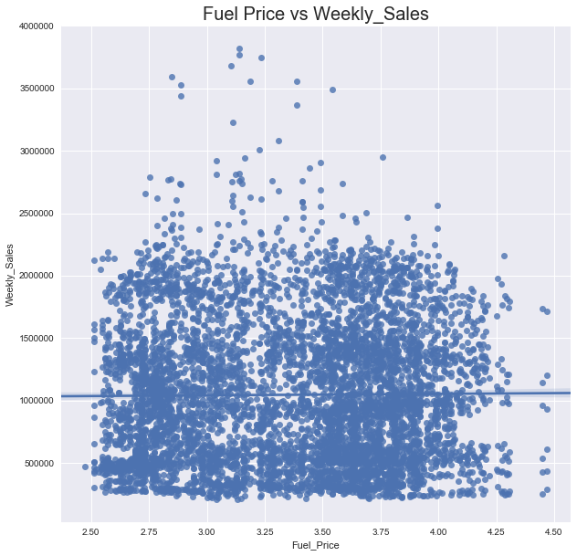

```python
plt.figure(figsize=(10,10))
sns.regplot(x="Fuel_Price", y="Weekly_Sales", data=df)
plt.title("Fuel Price vs Weekly_Sales", fontsize=20)
plt.show()
```

```python
plt.figure(figsize=(10,10))

x = fp
y = ws

plt.scatter(x=x, y=y, alpha=0.5)
plt.xlabel("Fuel Price ($)")
plt.ylabel("Weekly Sales (in Million)")
plt.title("Weekly_Sales vs Fuel_Price")
plt.show()
```

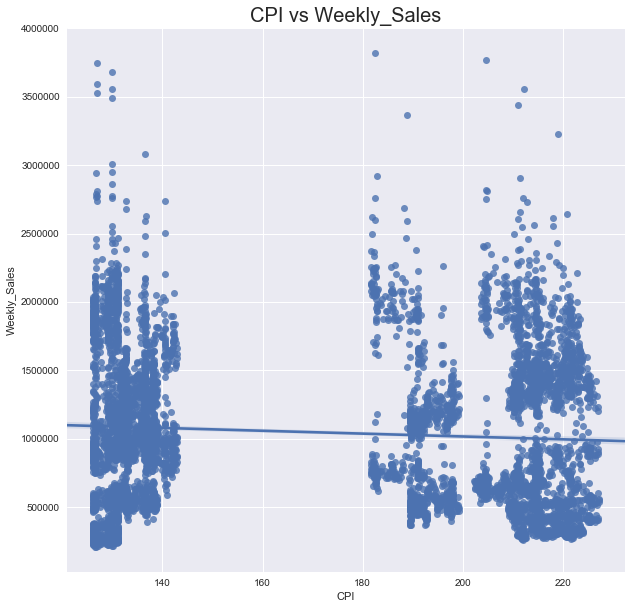

```python
plt.figure(figsize=(10,10))
sns.regplot(x="CPI", y="Weekly_Sales", data=df)
plt.title("CPI vs Weekly_Sales", fontsize=20)
plt.show()
```

```python
plt.figure(figsize=(10,10))

x = cpi
y = ws

plt.scatter(x=x, y=y, alpha=0.5)
plt.xlabel("CPI")
plt.ylabel("Weekly Sales (in Million)")
plt.title("Weekly_Sales vs CPI")
plt.show()
```

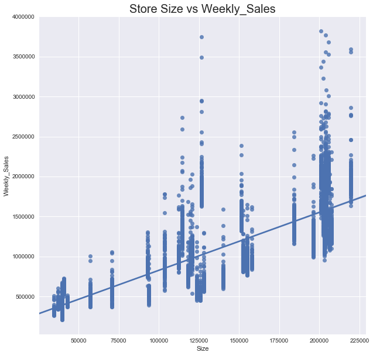

```python
plt.figure(figsize=(10,10))
sns.regplot(x="Size", y="Weekly_Sales", data=df)
plt.title("Store Size vs Weekly_Sales", fontsize=20)
plt.show()
```

```python
plt.figure(figsize=(10,10))

x = size
y = ws

plt.scatter(x=x, y=y, alpha=0.5)
plt.xlabel("Store Size")
plt.ylabel("Weekly Sales (in Million)")
plt.title("Weekly_Sales vs Store Size")
plt.show()
```

## Heatmap

### Dependent vs Independent Variables

With the hint from above correlation plots, the store size (Independent var.) correlates the most with the Store Weekly_Sales (Dependent var). To be able to verfy this matter, we are going to show correlation values in numeric format as the following heatmap. The values reflects the same result that store size is the only feature has a correlation value higher than 0.5. The rest of the features show very least correlation with the dependent variable Weekly_sales. In this case, I would suggest to compare the prediction results from the models which are with or without least correlated features. Hypothesis Tests will be proceeded to verify this results.

### Independent vs Independent Variables

For the correlation between independent variables, we could also observe that they don't have high correlation. I would not consider to remove any of the features at this point. Same as above, Hypothesis Tests will be proceeded to verify this results.

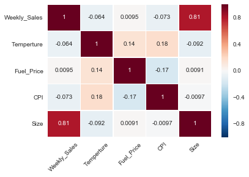

```python
import matplotlib.pyplot as plt
import seaborn as sns

df2 = df.copy()
df2.drop(columns=["Unnamed: 0","store","date"], inplace=True)

df2_corr =df2.corr()
sns.heatmap(df2_corr, linewidths=0.5, annot=True)
plt.xticks(rotation=45)
#plt.show()
```

## Hypotheses Test: (Dependent vs Independent Variables)

- Null Hypothesis H0: features (i.e. Temperature, Fuel_Price, CPI, Store Size) completely NOT correlates with the Store Weekly Sales.
- Alt. Hypothesis Ha: Features correlates with the Store Weekly Sales.

Acccording to the following Hypotheses Test for the features Temperature, CPI and Store Size with either (Z = -5) < -3 or (Z = 65) > 3 which means the p-value is more than 3 standard deviation below the mean. In other words, it shows more than 99.7% of chance the correlation of samples are not the same as the population mean. So that we have strong evidence to **reject the Null Hypotheses and proves that all of the features, except Fuel_Price, correlates with Store Weekly Sales**. The result also aligns the correlation values above heatmap, e.g. Correlation of FP vs Weekly_Sales = 0.0095. As mentioned, I would not remove any features during the initial Machine Learning process even though some of the features have low correlation values against Weekly_Sales(Dependant Variable). In addition, we might want to compare the performance of models which are built with or without those least correlated features.

```python
#Calculate pearson correlation function
def pearson_r(x,y):
    corr_mat = np.corrcoef(x,y)
    return corr_mat[0,1]

#Calculate P-value function
def p_value(array, value):
    return (value - np.mean(array))/np.std(array)
```

```python
xi = temp
yi = ws

No_bootstrap_trial = len(ws)
coef_lst=[]
for i in range(No_bootstrap_trial):
    x  = np.random.permutation(xi)
    y  = np.random.permutation(yi)
    coef_lst.append(np.corrcoef(x,y)[0,1])

org_coef = np.corrcoef(xi,yi)
p_val = p_value(coef_lst, org_coef)
print("The Z value for Temperature vs Weekly Sales is", p_val[0,1])
```

```
The Z value for Temperature vs Weekly Sales is -5.074510212722808
```

```python
xi = fp
yi = ws

No_bootstrap_trial = len(ws)
coef_lst=[]
for i in range(No_bootstrap_trial):
    x  = np.random.permutation(xi)
    y  = np.random.permutation(yi)
    coef_lst.append(np.corrcoef(x,y)[0,1])

org_coef = np.corrcoef(xi,yi)
p_val = p_value(coef_lst, org_coef)
print("The Z value for Fuel_Price vs Weekly Sales is", p_val[0,1])
```

```
The Z value for Fuel_Price vs Weekly Sales is 0.7416959324358041
```

```python
xi = cpi
yi = ws

No_bootstrap_trial = len(ws)
coef_lst=[]
for i in range(No_bootstrap_trial):
    x  = np.random.permutation(xi)
    y  = np.random.permutation(yi)
    coef_lst.append(np.corrcoef(x,y)[0,1])

org_coef = np.corrcoef(xi,yi)
p_val = p_value(coef_lst, org_coef)
print("The Z value for CPI vs Weekly Sales is", p_val[0,1])
```

```
The Z value for CPI vs Weekly Sales is -5.822494351406381
```

```python
xi = size
yi = ws

No_bootstrap_trial = len(ws)
coef_lst=[]
for i in range(No_bootstrap_trial):
    x  = np.random.permutation(xi)
    y  = np.random.permutation(yi)
    coef_lst.append(np.corrcoef(x,y)[0,1])

org_coef = np.corrcoef(xi,yi)
p_val = p_value(coef_lst, org_coef)
print("The Z value for Store Size vs Weekly Sales is", p_val[0,1])
```

```
The Z value for Store Size vs Weekly Sales is 64.75261639115354
```

## Hypotheses Test: (Store Size vs Other Independent Variables)

- Null Hypothesis H0: **Store Size** completely NOT correlates with other features (i.e. Temperature, Fuel_Price, CPI) .
- Alt. Hypothesis Ha: **Store Size** correlates with other features.

```python
xi = size
yi = cpi

No_bootstrap_trial = len(size)
coef_lst=[]
for i in range(No_bootstrap_trial):
    x  = np.random.permutation(xi)
    y  = np.random.permutation(yi)
    coef_lst.append(np.corrcoef(x,y)[0,1])

org_coef = np.corrcoef(xi,yi)
p_val = p_value(coef_lst, org_coef)
print("The Z value for Store Size vs CPI is", p_val[0,1])
```

```
The Z value for Store Size vs CPI is -0.7591189633258936
```

```python
xi = size
yi = fp

No_bootstrap_trial = len(size)
coef_lst=[]
for i in range(No_bootstrap_trial):
    x  = np.random.permutation(xi)
    y  = np.random.permutation(yi)
    coef_lst.append(np.corrcoef(x,y)[0,1])

org_coef = np.corrcoef(xi,yi)
p_val = p_value(coef_lst, org_coef)
print("The Z value for Store Size vs Fuel Price is", p_val[0,1])
```

```
The Z value for Store Size vs Fuel Price is 0.7204540835508108
```

```python
xi = size
yi = temp

No_bootstrap_trial = len(size)
coef_lst=[]
for i in range(No_bootstrap_trial):
    x  = np.random.permutation(xi)
    y  = np.random.permutation(yi)
    coef_lst.append(np.corrcoef(x,y)[0,1])

org_coef = np.corrcoef(xi,yi)
p_val = p_value(coef_lst, org_coef)
print("The Z value for Store Size vs Temperature is", p_val[0,1])
```

```
The Z value for Store Size vs Temperature is -7.449424467507209
```

## Hypotheses Test: (Temperature vs Other Independent Variables)

- Null Hypothesis H0: **Temperature** completely NOT correlates with other features (i.e. Fuel_Price, CPI) .
- Alt. Hypothesis Ha: **Temperature** correlates with other features.

```python
xi = fp
yi = temp

No_bootstrap_trial = len(temp)
coef_lst=[]
for i in range(No_bootstrap_trial):
    x  = np.random.permutation(xi)
    y  = np.random.permutation(yi)
    coef_lst.append(np.corrcoef(x,y)[0,1])

org_coef = np.corrcoef(xi,yi)
p_val = p_value(coef_lst, org_coef)
print("The Z value for Temperature vs Fuel Price is", p_val[0,1])
```

```
The Z value for Temperature vs Fuel Price is 11.659688455503828
```

```python
xi = cpi
yi = temp

No_bootstrap_trial = len(temp)
coef_lst=[]
for i in range(No_bootstrap_trial):
    x  = np.random.permutation(xi)
    y  = np.random.permutation(yi)
    coef_lst.append(np.corrcoef(x,y)[0,1])

org_coef = np.corrcoef(xi,yi)
p_val = p_value(coef_lst, org_coef)
print("The Z value for Temperature vs CPI is", p_val[0,1])
```

```
The Z value for Temperature vs CPI is 14.158387167148087
```

## Hypotheses Test: (Fuel Price vs CPI)

- Null Hypothesis H0: **Fuel Price** completely NOT correlates with CPI.
- Alt. Hypothesis Ha: **Fuel Price** correlates with CPI.

```python
xi = cpi
yi = fp

No_bootstrap_trial = len(fp)
coef_lst=[]
for i in range(No_bootstrap_trial):
    x  = np.random.permutation(xi)
    y  = np.random.permutation(yi)
    coef_lst.append(np.corrcoef(x,y)[0,1])

org_coef = np.corrcoef(xi,yi)
p_val = p_value(coef_lst, org_coef)
print("The Z value for Fuel Price vs CPI is", p_val[0,1])
```

```
The Z value for Fuel Price vs CPI is -13.629391944749145
```

## Summary

The above Hypothesis tests are able to give us some hints how the independent features react with each other and how the correlations between dependent and independent features. The most correlated feature against Weekly Sales (i.e. independent variable) is **Store Size** and the rest of independent features are comparably less correlated. In this part, we definitly give ourselves some insights prior to the machine learning part. Based on this analysis, we could iterate models with more features combinations in order to search out the most efficient and outperformed model.